# Health Status by access to a Usual Place of Healthcare: A view through individual self-reports

## By: Chris E, Lisbeth V, Jessie Z

## Introduction

With life expectancy nearly doubling in the last century, the United States has come a long way in improving healthcare. In 1900, life expectancy was 47 years and in 2019, it was 79 years (7). Much of this improvement in life expectancy can be attributed to the increasing amount of treatment for diseases. Recently, however, the United States has also seen rising trends of morbidity and chronic illness. Although the average life expectancy has grown, the average number of years living with morbidity has also increased. In an analysis comparing young adults in 1998 and 2006, researchers found that individuals in 2006 would live 1.1 additional years, but spend 2.3 more years with serious disease and 2 more years with limited mobility (7). For those 50 years and older, the number of people with at least one chronic disease is estimated to increase by 99.5% from 2020 to 2050 (5). One of the first places of treatment for serious or chronic illness is a primary care clinic or physician. Here, patients receive preventative care, screenings, and regular check ups. Many patients even visit primary care multiple times a year. Research has shown that primary care promotes overall health for many patients, preventing illness and death, whether the care is primarily through physicians, the patient’s relationship with a source of care, or the patient’s reception of care (4). Given this, we are interested in exploring the relationship between individuals having a usual place for care and their health status and the implications of this relationship.

## Motivation

Research has shown the link between health and the economy. Individuals having good health has a positive and statistically significant effect on aggregate economic growth. In general, healthy workers are more productive and earn higher wages than unhealthy workers. Life expectancy is also correlated with economic growth, and health contributes to life expectancy. A one-year improvement in a population’s life expectancy contributes to on average a four percent increase in output (1). Outside of productivity, health is related to labor participation. Health has a significant and positive effect on an individual’s participation in the labor force. A one unit increase in latent health increases the latent amount of participation in the labor force by 41% for males and 23% for females. In addition, a change from excellent to poor health reduces the probability of labor participation by 7.8% and 13.9% for males and females, respectively. Further, the relationship between health and labor participation is nonlinear, so changes in health at the lower end have greater effects on labor participation (2). For a country, economic growth is important to support their citizens and maintain their political positioning. Economic growth is affected by many factors–health being one of them. Therefore, it is important to study methods of improving population health, the healthcare system, and other factors that play into a nation’s overall health.

## Literature Review

### Article 1

David E. Bloom, David Canning, Jaypee Sevilla, The Effect of Health on Economic Growth: A Production Function Approach, World Development, Volume 32, Issue 1, 2004, Pages 1-13, ISSN 0305-750X, https://doi.org/10.1016/j.worlddev.2003.07.002. (https://www.sciencedirect.com/science/article/pii/S0305750X03001943)

The authors of this paper estimate a production function model of economic growth using work experience and health. In general, good health has a positive and statistically significant effect on aggregate economic growth, as healthier workers are more productive and can earn higher wages. In addition, health is correlated with life expectancy, which also affects economic growth, with a one-year improvement in a population’s life expectancy contributing to a four percent increase in output.

### Article 2

Lixin Cai, The relationship between health and labour force participation: Evidence from a panel data simultaneous equation model, Labour Economics, Volume 17, Issue 1, 2010, Pages 77-90,ISSN 0927-5371, https://doi.org/10.1016/j.labeco.2009.04.001. (https://www.sciencedirect.com/science/article/pii/S0927537109000426)

This study examines the relationship between health and labor force participation for both males and females. As a result, the authors found that health has a positive and significant effect on labor force participation. In addition, labor force participation has a negative effect on male health but has a positive effect on female health, implying that ,on average, males typically will not use poor health to justify non-participation but females will. A one unit increase in latent health increases the latent value of participation by about 41 percent for males and 23 percent for females, by the model used in this paper. In addition, a change from excellent to poor health reduces the probability of labor participation by 7.8 percent for males and 13.9 percent for females. The effect of health is also nonlinear, with changes in health at the lower end having greater effects than change at the upper end. Lastly, the effect of health on participation is larger for females than males.

### Article 3

Blewett, Lynn A et al. “When a usual source of care and usual provider matter: adult prevention and screening services.” Journal of general internal medicine vol. 23,9 (2008): 1354-60. doi:10.1007/s11606-008-0659-0. https://pubmed.ncbi.nlm.nih.gov/18506542/

The authors of this paper studied the relationship between adults having a usual place and provider for care with their reception of screening and prevention services, through the receipt of five preventative services: flu vaccine, Pap smear, mammogram, clinical breast exam, and prostate specific antigen. As a result, having a usual place and provider for care is associated with a higher likelihood of preventative care/ screening services for adults. Adults 50-64 with a usual place/provider had a 2.8 times greater chance of receiving a flu shot, compared to those without a usual place/provider for care. Men 50-64 had a 10 times greater chance of receiving a PSA test. For women ages , those with a usual place/provider had a 3.9 times greater chance of receiving a clinical breast exam for ages 20-64, 4.8 times higher chance of receiving a mammogram for ages 40-64, and 4.1 times greater chance for Pap smear testing for ages 21-64. Findings in this study contribute to the research around the healthcare model for delivery of care relying on predictive health.

### Article 4

Starfield, Barbara et al. “Contribution of primary care to health systems and health.” The Milbank quarterly vol. 83,3 (2005): 457-502. doi:10.1111/j.1468-0009.2005.00409.x. https://pubmed.ncbi.nlm.nih.gov/16202000/.

Research has shown that primary care promotes overall health for many individuals. Primary care contributes to preventing illness and death, whether the care is primarily through physicians, the patient’s relationship with a source of care, or the patient’s reception of care. Primary care is also associated with a more equitable distribution of health as opposed to specialty care. This paper discusses six reasons for the positive impact of primary care on population health: increased accessibility, better quality of care, more focus on prevention, preventative healthcare, the cumulative effect of consistent healthcare, and the reduction of potential unnecessary specialist care.

### Article 5

Ansah, John P, and Chi-Tsun Chiu. “Projecting the chronic disease burden among the adult population in the United States using a multi-state population model.” Frontiers in public health vol. 10 1082183. 13 Jan. 2023, doi:10.3389/fpubh.2022.1082183. https://www.frontiersin.org/articles/10.3389/fpubh.2022.1082183/full.

This paper explores the trend of rising chronic disease in the United States. The authors looked at populations accross multiple states by arranging people into three groups: healthy, one chronic condition, and multimorbidity. As a result, the authors found that from 2020 to 2050, the number of people in the United States ages 50 and older will increase by 61,11%, which is roughly 137.25 to 221.13 million people. Of that older population, the number with at least one chronic disease is estimated to increase 99.5% from 2020 to 2050. In addition, multimorbidity is expected to increase 91.16% in that time frame.

### Article 6

Freeman, Kris S. “U.S. lives: longer but sicker?.” Environmental health perspectives vol. 119,3 (2011): a118. doi:10.1289/ehp.119-a118a. https://www.ncbi.nlm.nih.gov/pmc/articles/PMC3060013/.

This paper discusses the increasing trend of disease and sickness in the United States in the last couple of decades. Although the average life expectancy has grown, the average number of years living with morbidity has also increased. However, despite this increase in life expectancy, the US still falls behind many other countries in increasing longevity. In addition, the increase in life expectancy is caused mostly by improvements in disease treatment as opposed to disease prevention.

#### Additional Citations

Article 7

Shmerling, Robert H. “Why Life Expectancy in the US Is Falling.” Harvard Health, Harvard Health Publishing, www.health.harvard.edu/blog/why-life-expectancy-in-the-us-is-falling-202210202835.

Article 8

Ashman, Jill J., et al. National Health Statistics Reports - Centers for Disease Control and Prevention, U.S. Department of Health and Human Services, www.cdc.gov/nchs/data/nhsr/nhsr184.pdf.

## Data Source

The data used in this project is from the IPUMS National Health Interview Survey. IPUMS contains census and survey data from around the world. IPUMS Health Surveys contains annual individual survey data from the 1960s to present. This project focuses on two variables, HEALTH and USUALPL. HEALTH provides an individual’s self-reported general health on a five-point scale, ranging from “excellent” to “poor.” The survey contains responses for children and adults 18 and over. USUALPL provides whether an individual has a place that they usually go to for healthcare. The survey contains responses from children and adults 18 and over.The project is analyzing survey responses from 2018.

## Project Code

We start by importing necessary packages and finding our working directory.

```python
import numpy as np
import pandas as pd
import seaborn as sns
import scipy.stats as stats
import matplotlib.pyplot as plt
from scipy.stats import ttest_ind
from statsmodels.stats.proportion import proportions_ztest
```

```python
import os
path = os.getcwd()
print(path)

data = pd.read_csv(r"/Users/jessie/Desktop/Econ 220 Lab/Data/nhis_00003.csv")
```

```
/Users/jessie/Desktop/Econ 220 Lab
```

We analyze the data and the data's info.

```python
data
```

|  | YEAR | SERIAL | STRATA | PSU | NHISHID | HHWEIGHT | PERNUM | NHISPID | HHX | FMX | ... | PERWEIGHT | SAMPWEIGHT | FWEIGHT | ASTATFLG | CSTATFLG | AGE | SEX | RACENEW | HEALTH | USUALPL |
| --- | --- | --- | --- | --- | --- | --- | --- | --- | --- | --- | --- | --- | --- | --- | --- | --- | --- | --- | --- | --- | --- |
| 0 | 2018 | 1 | 7103 | 19 | 2018000001 | 3338 | 1 | 20180000010101 | 1 | 1 | ... | 3539 | 3915.0 | 3539 | 1 | 0 | 79 | 2 | 100 | 3 | 2 |
| 1 | 2018 | 3 | 7137 | 38 | 2018000004 | 5188 | 1 | 20180000040101 | 4 | 1 | ... | 5656 | 0.0 | 5656 | 3 | 0 | 55 | 2 | 100 | 3 | 0 |
| 2 | 2018 | 3 | 7137 | 38 | 2018000004 | 5188 | 2 | 20180000040102 | 4 | 1 | ... | 5848 | 0.0 | 5656 | 2 | 0 | 49 | 1 | 100 | 3 | 0 |
| 3 | 2018 | 3 | 7137 | 38 | 2018000004 | 5188 | 3 | 20180000040103 | 4 | 1 | ... | 5886 | 6055.0 | 5656 | 0 | 1 | 16 | 1 | 100 | 3 | 2 |
| 4 | 2018 | 4 | 7106 | 22 | 2018000006 | 5259 | 1 | 20180000060101 | 6 | 1 | ... | 6009 | 16978.0 | 5415 | 1 | 0 | 37 | 1 | 100 | 3 | 2 |
| ... | ... | ... | ... | ... | ... | ... | ... | ... | ... | ... | ... | ... | ... | ... | ... | ... | ... | ... | ... | ... | ... |
| 72826 | 2018 | 46495 | 7121 | 6 | 2018055557 | 7097 | 1 | 20180555570101 | 55557 | 1 | ... | 7146 | 11808.0 | 7146 | 1 | 0 | 49 | 2 | 200 | 4 | 2 |
| 72827 | 2018 | 46498 | 7130 | 23 | 2018055560 | 7835 | 1 | 20180555600101 | 55560 | 1 | ... | 7902 | 9657.0 | 7902 | 1 | 0 | 40 | 2 | 100 | 5 | 2 |
| 72828 | 2018 | 46499 | 7137 | 19 | 2018055562 | 6791 | 1 | 20180555620101 | 55562 | 1 | ... | 7421 | 16525.0 | 6485 | 1 | 0 | 61 | 2 | 100 | 1 | 2 |
| 72829 | 2018 | 46499 | 7137 | 19 | 2018055562 | 6791 | 2 | 20180555620102 | 55562 | 1 | ... | 6485 | 0.0 | 6485 | 3 | 0 | 66 | 1 | 100 | 1 | 0 |
| 72830 | 2018 | 46500 | 7108 | 114 | 2018055563 | 1411 | 1 | 20180555630101 | 55563 | 1 | ... | 1387 | 1322.0 | 1387 | 1 | 0 | 70 | 2 | 100 | 2 | 2 |

72831 rows × 21 columns

```python
data.info()
```

```
<class 'pandas.core.frame.DataFrame'>
RangeIndex: 72831 entries, 0 to 72830
Data columns (total 21 columns):
 #   Column      Non-Null Count  Dtype
---  ------      --------------  -----
 0   YEAR        72831 non-null  int64
 1   SERIAL      72831 non-null  int64
 2   STRATA      72831 non-null  int64
 3   PSU         72831 non-null  int64
 4   NHISHID     72831 non-null  int64
 5   HHWEIGHT    72831 non-null  int64
 6   PERNUM      72831 non-null  int64
 7   NHISPID     72831 non-null  int64
 8   HHX         72831 non-null  int64
 9   FMX         72831 non-null  int64
 10  PX          72831 non-null  int64
 11  PERWEIGHT   72831 non-null  int64
 12  SAMPWEIGHT  72831 non-null  float64
 13  FWEIGHT     72831 non-null  int64
 14  ASTATFLG    72831 non-null  int64
 15  CSTATFLG    72831 non-null  int64
 16  AGE         72831 non-null  int64
 17  SEX         72831 non-null  int64
 18  RACENEW     72831 non-null  int64
 19  HEALTH      72831 non-null  int64
 20  USUALPL     72831 non-null  int64
dtypes: float64(1), int64(20)
memory usage: 11.7 MB
```

For further analysis, we created a dataframe with the following variables: age, sex, race, health status, and usual place of medical care.

```python
df = data[['AGE', 'SEX', 'RACENEW', 'HEALTH', 'USUALPL']]
```

## Demographic Variables

AGE

- We created a dummy variable for AGE classifying individuals as 'Over 18' if the value in the column is greater than or equal to 18. Then, we converted the AGE variable into a categorical variable with groupings by age range. 'Under 18' was defined as 0-17, '18-65' as 18-65, and 'Over 65' as 65 or older.

SEX

- We created a dummy variable for SEX by creating a value 'Female' for every value of SEX that equaled 2. This variable was converted to an integer, and the result is a value of 1 for for Female, and 0 for Male.

RACE

- We created three variables for race: white, black, and other. We defined three functions to create each variable and then converted them to float. Then, we grouped them into a comprehensive race variable with 'White', 'Black, and 'Other.'

All demographic variables were clean when imported from IPUMS. They were inspected before conversions.

### AGE

We inspect data and observe that AGE is already clean.

```python
df['AGE'].value_counts()
```

```
85    1385
55    1058
10    1046
60    1029
59    1027
      ...
79     368
81     299
82     289
83     256
84     207
Name: AGE, Length: 86, dtype: int64
```

```python
df['Over 18'] = df['AGE'] >=18
df[['AGE','Over 18']]
```

|  | AGE | Over 18 |
| --- | --- | --- |
| 0 | 79 | True |
| 1 | 55 | True |
| 2 | 49 | True |
| 3 | 16 | False |
| 4 | 37 | True |
| ... | ... | ... |
| 72826 | 49 | True |
| 72827 | 40 | True |
| 72828 | 61 | True |
| 72829 | 66 | True |
| 72830 | 70 | True |

72831 rows × 2 columns

```python
df['Over 18'] = df['Over 18'].astype('float')
df['Over 18'].dtype
```

```
dtype('float64')
```

```python
group = ['Under 18', '18-65', 'Over 65']
limit = [0, 18, 65, 100]

df['AGECAT'] = pd.cut(df['AGE'], bins=limit, labels=group, right=False)
df['AGECAT'].value_counts(sort=False)
```

```
Under 18    16666
18-65       43253
Over 65     12912
Name: AGECAT, dtype: int64
```

### SEX

The sex variable is already clean.

```python
df['SEX'].value_counts()
```

```
2    37282
1    35549
Name: SEX, dtype: int64
```

```python
df['Female'] = df['SEX']==2
df['Female'] = df['Female'].astype(int)
df[['SEX', 'Female']]
```

|  | SEX | Female |
| --- | --- | --- |
| 0 | 2 | 1 |
| 1 | 2 | 1 |
| 2 | 1 | 0 |
| 3 | 1 | 0 |
| 4 | 1 | 0 |
| ... | ... | ... |
| 72826 | 2 | 1 |
| 72827 | 2 | 1 |
| 72828 | 2 | 1 |
| 72829 | 1 | 0 |
| 72830 | 2 | 1 |

72831 rows × 2 columns

```python
df['Female']=df['Female'].astype('float')
df['Female'].dtype
```

```
dtype('float64')
```

### RACE

After inspection, we find that RACENEW is clean.

```python
df['RACENEW'].value_counts()
```

```
100    56435
200     8497
400     4513
541     2117
300      998
530      271
Name: RACENEW, dtype: int64
```

```python
def white(x):
    if x==100:
        return 1
    else:
        return 0

df['White'] = df['RACENEW'].apply(white)
df[['RACENEW', 'White']]
```

|  | RACENEW | White |
| --- | --- | --- |
| 0 | 100 | 1 |
| 1 | 100 | 1 |
| 2 | 100 | 1 |
| 3 | 100 | 1 |
| 4 | 100 | 1 |
| ... | ... | ... |
| 72826 | 200 | 0 |
| 72827 | 100 | 1 |
| 72828 | 100 | 1 |
| 72829 | 100 | 1 |
| 72830 | 100 | 1 |

72831 rows × 2 columns

```python
df['White'] = df['White'].astype('float')
df['White'].dtypes
```

```
dtype('float64')
```

```python
def black(x):
    if x==200:
        return 1
    else:
        return 0

df['Black'] = df['RACENEW'].apply(black)
df[['RACENEW', 'Black']]
```

|  | RACENEW | Black |
| --- | --- | --- |
| 0 | 100 | 0 |
| 1 | 100 | 0 |
| 2 | 100 | 0 |
| 3 | 100 | 0 |
| 4 | 100 | 0 |
| ... | ... | ... |
| 72826 | 200 | 1 |
| 72827 | 100 | 0 |
| 72828 | 100 | 0 |
| 72829 | 100 | 0 |
| 72830 | 100 | 0 |

72831 rows × 2 columns

```python
df['Black'] = df['Black'].astype('float')
df['Black'].dtypes
```

```
dtype('float64')
```

```python
def other(x):
    if x>=300:
        return 1
    else:
        return 0

df['Other']=df['RACENEW'].apply(other)
df[['RACENEW','Other']]
```

|  | RACENEW | Other |
| --- | --- | --- |
| 0 | 100 | 0 |
| 1 | 100 | 0 |
| 2 | 100 | 0 |
| 3 | 100 | 0 |
| 4 | 100 | 0 |
| ... | ... | ... |
| 72826 | 200 | 0 |
| 72827 | 100 | 0 |
| 72828 | 100 | 0 |
| 72829 | 100 | 0 |
| 72830 | 100 | 0 |

72831 rows × 2 columns

```python
df['Other'] = df['Other'].astype('float')
df['Other'].dtypes
```

```
dtype('float64')
```

```python
group = ['White', 'Black', 'Other']
limit = [0, 101, 201, 999]

df['Race']=pd.cut(df['RACENEW'], bins=limit, labels=group, right=False)
df['Race'].value_counts(sort=False)
```

```
White    56435
Black     8497
Other     7899
Name: Race, dtype: int64
```

## Variables of Interest

Now we will analyze the variables necesssary to answer our motivating question: Do individuals with a usual place for medical care have better health status?

To work with our variable USUALPL, we will create a new dummy variable. This will return 1 if the individual has a usual place of care, and 0 if they do not have a usual place of care.

```python
df['Usual_Place'] = df['USUALPL'] > 1

df['Usual_Place'] = df['Usual_Place'].astype(int)
df[['USUALPL', 'Usual_Place']]
```

|  | USUALPL | Usual_Place |
| --- | --- | --- |
| 0 | 2 | 1 |
| 1 | 0 | 0 |
| 2 | 0 | 0 |
| 3 | 2 | 1 |
| 4 | 2 | 1 |
| ... | ... | ... |
| 72826 | 2 | 1 |
| 72827 | 2 | 1 |
| 72828 | 2 | 1 |
| 72829 | 0 | 0 |
| 72830 | 2 | 1 |

72831 rows × 2 columns

Now, we will modify our HEALTH variable. The survey data is organized on a scale of 5-1 where 1 is reported as Excellent health, and 5 is reported as Poor health. For readability, we will restructure the data so that 1 is Poor health and 5 is Excellent health.

```python
def fhlth(x):
    if x==5:
        return 1
    elif x==4:
        return 2
    elif x==3:
        return 3
    elif x==2:
        return 4
    elif x==1:
        return 5
    elif x>5:
        return 0

df['Health_Status'] = df['HEALTH'].apply(fhlth)
df[['HEALTH','Health_Status']].head(40)
```

|  | HEALTH | Health_Status |
| --- | --- | --- |
| 0 | 3 | 3 |
| 1 | 3 | 3 |
| 2 | 3 | 3 |
| 3 | 3 | 3 |
| 4 | 3 | 3 |
| 5 | 2 | 4 |
| 6 | 1 | 5 |
| 7 | 1 | 5 |
| 8 | 2 | 4 |
| 9 | 1 | 5 |
| 10 | 1 | 5 |
| 11 | 5 | 1 |
| 12 | 2 | 4 |
| 13 | 2 | 4 |
| 14 | 2 | 4 |
| 15 | 2 | 4 |
| 16 | 2 | 4 |
| 17 | 1 | 5 |
| 18 | 3 | 3 |
| 19 | 2 | 4 |
| 20 | 4 | 2 |
| 21 | 4 | 2 |
| 22 | 3 | 3 |
| 23 | 1 | 5 |
| 24 | 1 | 5 |
| 25 | 1 | 5 |
| 26 | 2 | 4 |
| 27 | 2 | 4 |
| 28 | 4 | 2 |
| 29 | 2 | 4 |
| 30 | 4 | 2 |
| 31 | 4 | 2 |
| 32 | 1 | 5 |
| 33 | 1 | 5 |
| 34 | 3 | 3 |
| 35 | 3 | 3 |
| 36 | 3 | 3 |
| 37 | 2 | 4 |
| 38 | 2 | 4 |
| 39 | 2 | 4 |

## Summary Statistics

Below is a display of the summary statistics for the 'AGE', 'Female', 'White', 'Black', 'Other', 'HEALTH', 'USUALPL' variables.

```python
df[['AGE', 'Female', 'White', 'Black', 'Other', 'Health_Status', 'Usual_Place']].agg(['mean', 'std', 'min', 'max', 'count']).round(3)
```

|  | AGE | Female | White | Black | Other | Health_Status | Usual_Place |
| --- | --- | --- | --- | --- | --- | --- | --- |
| mean | 39.866 | 0.512 | 0.775 | 0.117 | 0.108 | 3.871 | 0.415 |
| std | 23.346 | 0.500 | 0.418 | 0.321 | 0.311 | 1.056 | 0.493 |
| min | 0.000 | 0.000 | 0.000 | 0.000 | 0.000 | 0.000 | 0.000 |
| max | 85.000 | 1.000 | 1.000 | 1.000 | 1.000 | 5.000 | 1.000 |
| count | 72831.000 | 72831.000 | 72831.000 | 72831.000 | 72831.000 | 72831.000 | 72831.000 |

The table shows that the average self reported rating for health status is fairly high being 3.871 out of a maximum of 5. Only about 41.5% of the people who self reported their health status had a ususal place for health care. Of those who participated, gender was split fairly evenly, with women accounting for about 51.2%, however, the majority of the participants were white accounting for 77.5% of survey respondents, while only about 11.7% were black.

## Plots

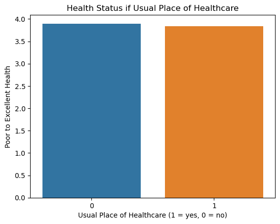

```python
bar1=sns.barplot(data=df, x='Usual_Place', y='Health_Status',ci=None)
bar1.set(title='Health Status if Usual Place of Healthcare', xlabel='Usual Place of Healthcare (1 = yes, 0 = no)', ylabel='Poor to Excellent Health');
```

The barplot shows that the average quality of self reported health amongst those with a ususal place of healthcare and those without a usual place of healthcare is relatively similiar. However, the group without a usual place of healthcare did report themselves to be on average slighlty healthier.

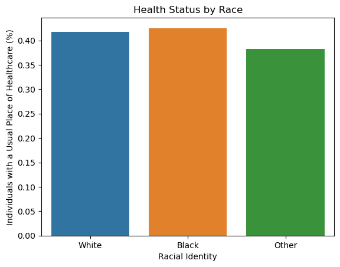

```python
bar2 = sns.barplot(data=df, x='Race', y='Usual_Place', ci=None)
bar2.set(title='Health Status by Race', xlabel='Racial Identity', ylabel='Individuals with a Usual Place of Healthcare (%)');
```

The barplot shows that amongst those who were white and those who were black, the average percent of those who had a usual place of healthcare was relatively similar. However, the average percent of those who identified as black who had a usual place of healthcare was slightly higher than than those who identified as white. Both of these groups however had a somewhat significally higher percentage of of people who have a ususal place of healthcare than those of other races.

# Hypothesis Tests

```python
summary = df[['AGE', 'Female', 'White', 'Black', 'Other', 'Health_Status', 'Usual_Place']]
summary = summary.dropna()
summary
```

|  | AGE | Female | White | Black | Other | Health_Status | Usual_Place |
| --- | --- | --- | --- | --- | --- | --- | --- |
| 0 | 79 | 1.0 | 1.0 | 0.0 | 0.0 | 3 | 1 |
| 1 | 55 | 1.0 | 1.0 | 0.0 | 0.0 | 3 | 0 |
| 2 | 49 | 0.0 | 1.0 | 0.0 | 0.0 | 3 | 0 |
| 3 | 16 | 0.0 | 1.0 | 0.0 | 0.0 | 3 | 1 |
| 4 | 37 | 0.0 | 1.0 | 0.0 | 0.0 | 3 | 1 |
| ... | ... | ... | ... | ... | ... | ... | ... |
| 72826 | 49 | 1.0 | 0.0 | 1.0 | 0.0 | 2 | 1 |
| 72827 | 40 | 1.0 | 1.0 | 0.0 | 0.0 | 1 | 1 |
| 72828 | 61 | 1.0 | 1.0 | 0.0 | 0.0 | 5 | 1 |
| 72829 | 66 | 0.0 | 1.0 | 0.0 | 0.0 | 5 | 0 |
| 72830 | 70 | 1.0 | 1.0 | 0.0 | 0.0 | 4 | 1 |

72831 rows × 7 columns

```python
# hypothesis test for difference in means in health by whether an individual has a usual place for care
usual = summary[summary['Usual_Place']==0]['Health_Status']
nousual = summary[summary['Usual_Place']==1]['Health_Status']
test_health=ttest_ind(usual, nousual)
test_health
print('Test-statistic: ', round(test_health[0],4))
print('P-value: ',round(test_health[1],15))
# p-value < 5%: statistically significant
```

```
Test-statistic:  7.8575
P-value:  4e-15
```

```python
# distributiuon of individuals with "poor" (1) health status by usual place of care
pd.crosstab(summary['Usual_Place'],summary['Health_Status'], margins=True)
```

| Health_Status Usual_Place | 0 | 1 | 2 | 3 | 4 | 5 | All |
| --- | --- | --- | --- | --- | --- | --- | --- |
| 0 | 66 | 892 | 3139 | 10213 | 13260 | 15037 | 42607 |
| 1 | 8 | 819 | 2683 | 7219 | 9423 | 10072 | 30224 |
| All | 74 | 1711 | 5822 | 17432 | 22683 | 25109 | 72831 |

```python
# hypothesis test for difference in proportions of individuals with "poor" health status by usual place of care
test_pro_phealth = proportions_ztest([808,52], [30065,3462])
test_pro_phealth
print('Test-statistic: ', round(test_pro_phealth[0],4))
print('P-value: ',round(test_pro_phealth[1],5))
# p value < 5%: significant
# there is evidence of a difference in the proportions of individuals with low health status by usual place of care
```

```
Test-statistic:  4.1782
P-value:  3e-05
```

```python
# hypothesis test for difference in proportions of individuals with "excellent" health status by usual place of care
test_pro_ehealth = proportions_ztest([10028,1196], [30065,3462])
test_pro_ehealth
print('Test-statistic: ', round(test_pro_ehealth[0],4))
print('P-value: ',round(test_pro_ehealth[1],4))
# p value > 5%: not significant
# there is no evidence of a difference in the proportions of individuals with "excellent" health status by usual place of care
```

```
Test-statistic:  -1.4075
P-value:  0.1593
```

# Conclusion